# Forecasting El Nino effect with ARIMA

### 2. Stationary report

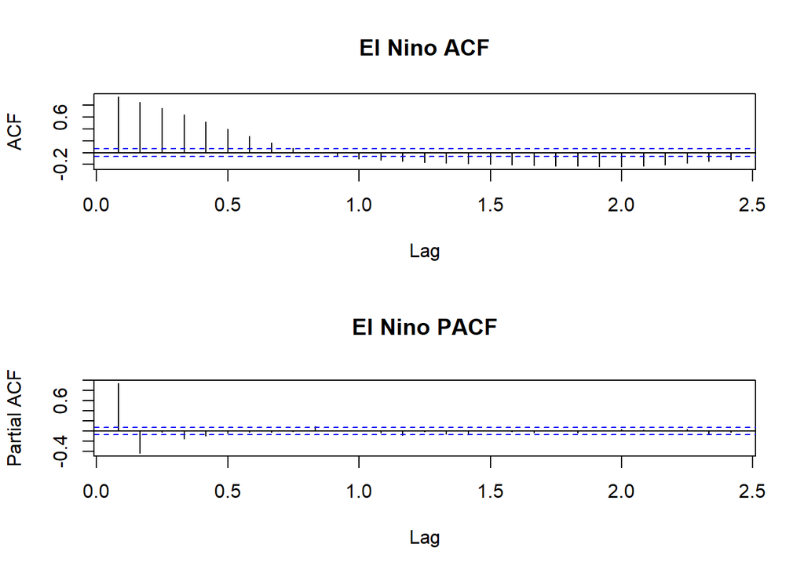

```r
# ACF and PACF on time series data

par(mfrow = c(2,1))

acf(el.nino.ts,
    main = "El Nino ACF")

pacf(el.nino.ts,
     main = "El Nino PACF")
```

```r
# Augmented Dickey-Fuller unit root test and KPSS test

result <- ar(diff(el.nino.ts))
result$order
```

```
## [1] 11
```

```r
adfTest(el.nino.ts,
        lags = result$order,
        type = ("c"))       # ADF test, no trend (c)
```

```
##
## Title:
##  Augmented Dickey-Fuller Test
##
## Test Results:
##   PARAMETER:
##     Lag Order: 11
##   STATISTIC:
##     Dickey-Fuller: -6.6515
##   P VALUE:
##     0.01
##
## Description:
##  Tue Feb 09 14:11:04 2021 by user: hwhua
```

```r
# KPSS test

kpss.test(el.nino.ts,
          null = "Level")
```

```
##
##  KPSS Test for Level Stationarity
##
## data:  el.nino.ts
## KPSS Level = 0.039651, Truncation lag parameter = 6, p-value = 0.1
```

## 3. Model Identification

```r
# EACF on time series data and information criteria (auto.arima)

eacf(el.nino.ts)
```

```
## AR/MA
##   0 1 2 3 4 5 6 7 8 9 10 11 12 13
## 0 x x x x x x x x x o o  x  x  x
## 1 x x x x x x x x x o x  x  o  o
## 2 o x o o o o o x o o o  o  x  o
## 3 o x x o o o o x x o o  o  o  o
## 4 x x x o o o o x x o o  x  o  o
## 5 x x x x x o o x o o o  o  o  o
## 6 x x x o x o o o o x x  o  o  o
## 7 x x o x x o o x o o x  o  o  o
```

```r
auto.arima(el.nino.ts,
           seasonal = FALSE)
```

```
## Series: el.nino.ts
## ARIMA(2,0,3) with zero mean
##
## Coefficients:
##          ar1      ar2      ma1      ma2     ma3
##       1.7916  -0.8300  -0.4172  -0.2586  0.0625
## s.e.  0.0490   0.0433   0.0582   0.0452  0.0458
##
## sigma^2 estimated as 0.05128:  log likelihood=56.2
## AIC=-100.41   AICc=-100.3   BIC=-72.06
```

#### Comments

- EACF suggests an AR(2) model while information criteria suggests ARIMA(2,0,3), we will compare these two models

## 4. Parameter Estimation

```r
# parameter estimation (maximum likelihood)


# estimation for ARIMA(2,0,0)

el.nino.fit.1 <- Arima(el.nino.ts,
                       order = c(2,0,0),
                       method = 'ML')

# estimation for ARIMA(2,0,3)

el.nino.fit.2 <- Arima(el.nino.ts,
                          order = c(2,0,3),
                          method = 'ML')
# result

el.nino.fit.1
```

```
## Series: el.nino.ts
## ARIMA(2,0,0) with non-zero mean
##
## Coefficients:
##          ar1      ar2    mean
##       1.3981  -0.4668  0.0187
## s.e.  0.0306   0.0307  0.1152
##
## sigma^2 estimated as 0.05308:  log likelihood=40.88
## AIC=-73.77   AICc=-73.72   BIC=-54.87
```

```r
el.nino.fit.2
```

```
## Series: el.nino.ts
## ARIMA(2,0,3) with non-zero mean
##
## Coefficients:
##          ar1      ar2      ma1      ma2     ma3    mean
##       1.8133  -0.8479  -0.4369  -0.2579  0.0255  0.0241
## s.e.  0.0490   0.0425   0.0584   0.0474  0.0492  0.0748
##
## sigma^2 estimated as 0.05138:  log likelihood=55.9
## AIC=-97.81   AICc=-97.67   BIC=-64.73
```

## 5. Diagnostic Testing

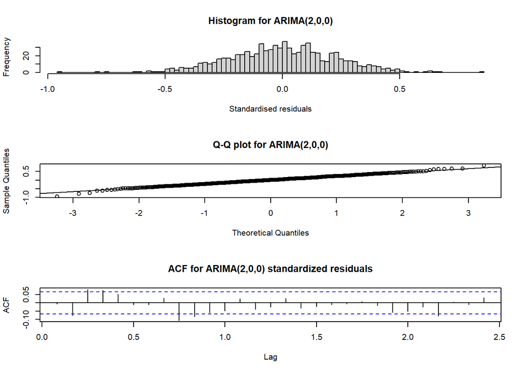

```r
# diagnostic testing

# model 1 ----------------------------------------------------------------------
par(mfrow = c(3,1))

hist(residuals(el.nino.fit.1),
     xlab = "Standardised residuals",
     main = "Histogram for ARIMA(2,0,0)",
     n = 100)

qqnorm(residuals(el.nino.fit.1),
       main = "Q-Q plot for ARIMA(2,0,0)")
qqline(residuals(el.nino.fit.1))

acf(residuals(el.nino.fit.1),
    main = "ACF for ARIMA(2,0,0) standardized residuals")
```

```r
# normality, autocorrelation and independent test

shapiro.test(residuals(el.nino.fit.1)) #normality
```

```
##
##  Shapiro-Wilk normality test
##
## data:  residuals(el.nino.fit.1)
## W = 0.99771, p-value = 0.3091
```

```r
runs(residuals(el.nino.fit.1))   #independent
```

```
## $pvalue
## [1] 0.733
##
## $observed.runs
## [1] 412
##
## $expected.runs
## [1] 417.4274
##
## $n1
## [1] 411
##
## $n2
## [1] 422
##
## $k
## [1] 0
```

```r
Box.test(residuals(el.nino.fit.1),     #autocorrelation
         lag = 10,
         type = "Ljung-Box",
         fitdf = 2)   # p+q
```

```
##
##  Box-Ljung test
##
## data:  residuals(el.nino.fit.1)
## X-squared = 34.855, df = 8, p-value = 2.841e-05
```

```r
# checking the p-value for lag 10 to lag 15

test.result <- list()
list.p.fit.1 <- list()

for (i in 10:15) {

  test.result[[i-9]] <- Box.test(residuals(el.nino.fit.1),
           lag = i,
           type = "Ljung-Box",
           fitdf = 2)

  list.p.fit.1[[i-9]] <- as.numeric(test.result[[i-9]]$p.value)

}

list.p.fit.1
```

```
## [[1]]
## [1] 2.841454e-05
##
## [[2]]
## [1] 1.831764e-05
##
## [[3]]
## [1] 1.783243e-05
##
## [[4]]
## [1] 3.0983e-05
##
## [[5]]
## [1] 3.790598e-05
##
## [[6]]
## [1] 6.043985e-05
```

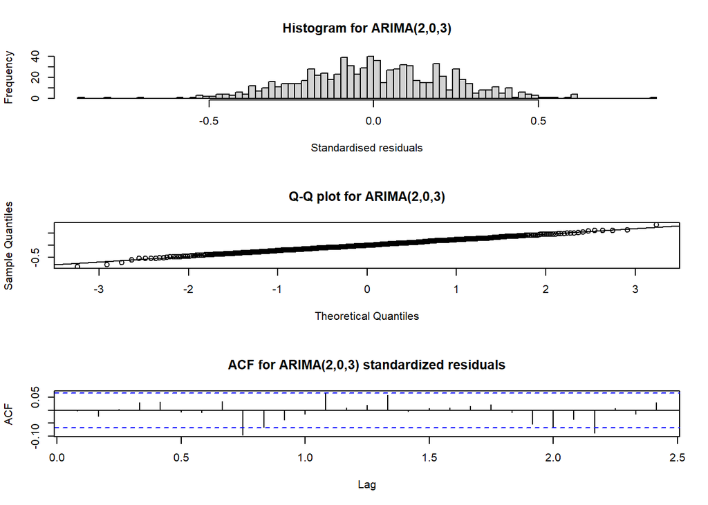

```r
# model 2 ----------------------------------------------------------------------

par(mfrow = c(3,1))

hist(residuals(el.nino.fit.2),
     xlab = "Standardised residuals",
     main = "Histogram for ARIMA(2,0,3)",
     n = 100)

qqnorm(residuals(el.nino.fit.2),
       main = "Q-Q plot for ARIMA(2,0,3)")
qqline(residuals(el.nino.fit.2))

acf(residuals(el.nino.fit.2),
    main = "ACF for ARIMA(2,0,3) standardized residuals")
```

```r
# normality, autocorrelation and independent test

shapiro.test(residuals(el.nino.fit.2))  #normality
```

```
##
##  Shapiro-Wilk normality test
##
## data:  residuals(el.nino.fit.2)
## W = 0.99812, p-value = 0.4974
```

```r
runs(residuals(el.nino.fit.2))   #independent
```

```
## $pvalue
## [1] 0.772
##
## $observed.runs
## [1] 422
##
## $expected.runs
## [1] 417.3265
##
## $n1
## [1] 425
##
## $n2
## [1] 408
##
## $k
## [1] 0
```

```r
Box.test(residuals(el.nino.fit.2),   #autocorrelation
         lag = 10,
         type = "Ljung-Box",
         fitdf = 5)  #p+q
```

```
##
##  Box-Ljung test
##
## data:  residuals(el.nino.fit.2)
## X-squared = 14.548, df = 5, p-value = 0.01248
```

```r
# checking the p-value for lag 10 to lag 15

test.result.2 <- list()
list.p.fit.2 <- list()

for (i in 10:15) {

  test.result.2[[i-9]] <- Box.test(residuals(el.nino.fit.2),
                                 lag = i,
                                 type = "Ljung-Box",
                                 fitdf = 5)

  list.p.fit.2[[i-9]] <- as.numeric(test.result.2[[i-9]]$p.value)

}

list.p.fit.2
```

```
## [[1]]
## [1] 0.01247913
##
## [[2]]
## [1] 0.01550536
##
## [[3]]
## [1] 0.02651104
##
## [[4]]
## [1] 0.01286559
##
## [[5]]
## [1] 0.02143022
##
## [[6]]
## [1] 0.03122482
```

#### Comments

The null hypothesis of Shapiro-wilk test is: H0: the studentized residuals are normally distributed. The null hypothesis of Run test is: H0: the studentized residuals are independent, i.e., the series is random. The null hypothesis of Box-Ljung test is: H0: the residuals are not correlated.

- Based on above testing and plots, we conclude the student residuals for AR(2) and ARIMA(2,0,3) are normally distributed and independent and correlated.
  - We should keep in mind that the correlation can potentially lead an issue while we analyzing the model, even the normality and independent assumptions are satisfied.

## 6. Forecasting and Model Selection

```r
# forecasting


el.nino.fit.1.forecast <- forecast(el.nino.fit.1,
                                       h = 36,  #next 3 years (36 months)
                                       level = 95)  # CI = 95

el.nino.fit.2.forecast <- forecast(el.nino.fit.2,
                                      h = 36,   #next 3 years (36 months)
                                      level = 95)  # CI = 95

# result of forcast

el.nino.fit.1.forecast
```

```
##          Point Forecast      Lo 95    Hi 95
## Jun 2019     0.56001392  0.1084418 1.011586
## Jul 2019     0.48552468 -0.2906967 1.261746
## Aug 2019     0.41871417 -0.6079323 1.445361
## Sep 2019     0.36007371 -0.8522362 1.572384
## Oct 2019     0.30927183 -1.0380226 1.656566
## Nov 2019     0.26561577 -1.1788600 1.710092
## Dec 2019     0.22829166 -1.2858146 1.742398
## Jan 2020     0.19648501 -1.3674065 1.760376
## Feb 2020     0.16943691 -1.4300266 1.768900
## Mar 2020     0.14646652 -1.4784155 1.771349
## Apr 2020     0.12697613 -1.5160768 1.770029
## May 2020     0.11044791 -1.5456022 1.766498
## Jun 2020     0.09643681 -1.5689152 1.761789
## Jul 2020     0.08456233 -1.5874505 1.756575
## Aug 2020     0.07450022 -1.6022843 1.751285
## Sep 2020     0.06597471 -1.6142295 1.746179
## Oct 2020     0.05875163 -1.6239042 1.741407
## Nov 2020     0.05263226 -1.6317815 1.737046
## Dec 2020     0.04744810 -1.6382265 1.733123
## Jan 2021     0.04305630 -1.6435226 1.729635
## Feb 2021     0.03933580 -1.6478919 1.726564
## Mar 2021     0.03618401 -1.6515092 1.723877
## Apr 2021     0.03351401 -1.6545132 1.721541
## May 2021     0.03125217 -1.6570147 1.719519
## Jun 2021     0.02933608 -1.6591027 1.717775
## Jul 2021     0.02771291 -1.6608493 1.716275
## Aug 2021     0.02633787 -1.6623128 1.714989
## Sep 2021     0.02517304 -1.6635412 1.713887
## Oct 2021     0.02418627 -1.6645736 1.712946
## Nov 2021     0.02335035 -1.6654422 1.712143
## Dec 2021     0.02264222 -1.6661738 1.711458
## Jan 2022     0.02204234 -1.6667905 1.710875
## Feb 2022     0.02153417 -1.6673108 1.710379
## Mar 2022     0.02110368 -1.6677500 1.709957
## Apr 2022     0.02073900 -1.6681209 1.709599
## May 2022     0.02043007 -1.6684343 1.709294
```

```r
el.nino.fit.2.forecast
```

```
##          Point Forecast      Lo 95    Hi 95
## Jun 2019    0.566240627  0.1219779 1.010503
## Jul 2019    0.465912103 -0.2899293 1.221753
## Aug 2019    0.367080192 -0.6089760 1.343136
## Sep 2019    0.271427227 -0.8810100 1.423864
## Oct 2019    0.181775769 -1.1117420 1.475293
## Nov 2019    0.100311606 -1.3035981 1.504221
## Dec 2019    0.028605061 -1.4588312 1.516041
## Jan 2020   -0.032349665 -1.5802608 1.515561
## Feb 2020   -0.082081219 -1.6713551 1.507193
## Mar 2020   -0.120577863 -1.7360821 1.494926
## Apr 2020   -0.148217960 -1.7786759 1.482240
## May 2020   -0.165697564 -1.8033812 1.471986
## Jun 2020   -0.173958035 -1.8142155 1.466299
## Jul 2020   -0.174116188 -1.8147744 1.466542
## Aug 2020   -0.167399005 -1.8081021 1.473304
## Sep 2020   -0.155084467 -1.7966348 1.486466
## Oct 2020   -0.138449627 -1.7822169 1.505318
## Nov 2020   -0.118726608 -1.7661731 1.528720
## Dec 2020   -0.097066854 -1.7494151 1.555281
## Jan 2021   -0.074513603 -1.7325578 1.583531
## Feb 2021   -0.051982287 -1.7160248 1.612060
## Mar 2021   -0.030248333 -1.7001318 1.639635
## Apr 2021   -0.009941659 -1.6851413 1.665258
## May 2021    0.008452967 -1.6712923 1.688198
## Jun 2021    0.024590603 -1.6588092 1.707990
## Jul 2021    0.038256785 -1.6478965 1.724410
## Aug 2021    0.049355096 -1.6387265 1.737437
## Sep 2021    0.057892537 -1.6314248 1.747210
## Oct 2021    0.063963558 -1.6260569 1.753984
## Nov 2021    0.067733493 -1.6226214 1.758088
## Dec 2021    0.069422057 -1.6210468 1.759891
## Jan 2022    0.069287487 -1.6211963 1.759771
## Feb 2022    0.067611751 -1.6228762 1.758100
## Mar 2022    0.064687196 -1.6258498 1.755224
## Apr 2022    0.060804865 -1.6298521 1.751462
## May 2022    0.056244632 -1.6346061 1.747095
```

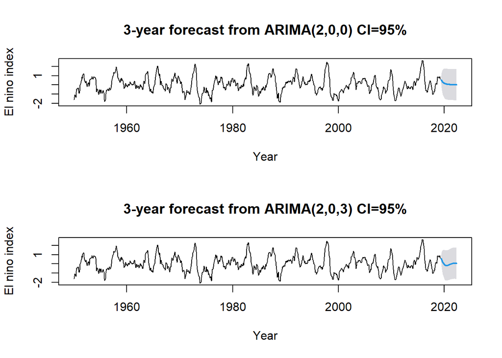

```r
# plot of forecast

par(mfrow = c(2,1))

plot(el.nino.fit.1.forecast,
     main="3-year forecast from ARIMA(2,0,0) CI=95%",
     ylab = "El nino index",
     xlab = "Year")

plot(el.nino.fit.2.forecast,
     main="3-year forecast from ARIMA(2,0,3) CI=95%",
     ylab = "El nino index",
     xlab = "Year")
```

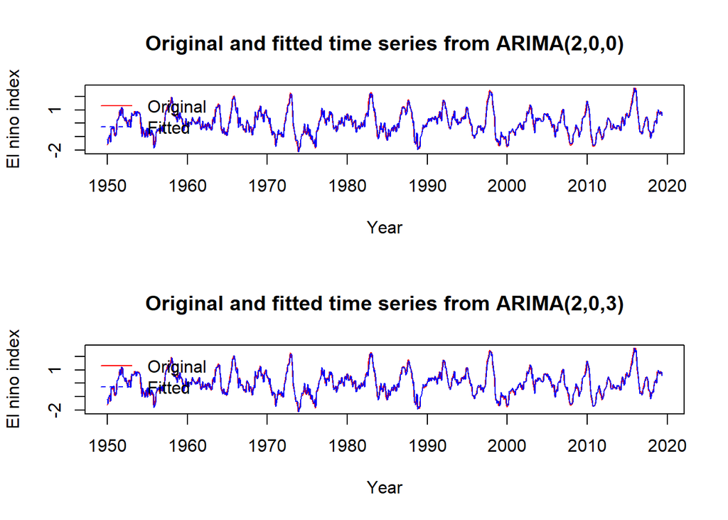

```r
# plot fitted values and the original time series (in-sample estimation)

par(mfrow=c(2,1))

# ARIMA(2,0,0) model

plot(el.nino.ts,
     col = "red",
     ylab = "El nino index",
     xlab = "Year",
     main = "Original and fitted time series from ARIMA(2,0,0)")

fitted <- el.nino.ts - el.nino.fit.1$residuals
lines(fitted, col="blue")

legend("topleft",
       c("Original","Fitted"),
       col = c("red","blue"),
       lty = 1:2,
       bty = "n")

# ARIMA(2,0,3) model

plot(el.nino.ts,
     col = "red",
     ylab = "El nino index",
     xlab = "Year",
     main = "Original and fitted time series from ARIMA(2,0,3)")

fitted <- el.nino.ts - el.nino.fit.2$residuals
lines(fitted, col="blue")

legend("topleft",
       c("Original","Fitted"),
       col = c("red","blue"),
       lty = 1:2,
       bty = "n")
```

```r
# ==============================================================================
# comparing forecast model and selection

#

# set up -----------------------------------------------------------------------

m <- 2              # two different ARIMA models
k <- 36             # suppose we want to make 24 forecast comparisons.  ## need to change this depends on what you want
n.obs <- length(el.nino.ts)
n.end <- n.obs-k    # Only use n.end observations for the first forecast, which starts at may 2016.
el.nino.ts.trun <- window(el.nino.ts,start=c(2016,5))       # the actual series from 2016 to 2019
pred <- matrix(rep(0,k * m),k,m)        # create a empty matrix that will be filled by forecast values

# generate two sequences of forecasts from two models
# step 1: use a subsample to build the model, and then do 1-period ahead forecast,
# step 2: increase the length of the subsample by 1 period and repeat step 1
for(i in 1:k){
  x <- el.nino.ts[1:n.end+i-1]
  model1.tmp <- Arima(x,order=c(2,0,0), method="ML")        # Candidate Model 1
  pred[i,1] <- forecast(model1.tmp,h=1)$mean[1]         # h=1 means 1-period ahead forecast; ## mean is the point forecast
  model2.tmp <- Arima(x,order=c(2,0,3), method="ML")        # Candidate Model 2
  pred[i,2] <- forecast(model2.tmp,h=1)$mean[1]         # h=1 means 1-period ahead forecast
}
pred.ts <- ts(pred, start=c(2016,5), frequency=12)

# plot last three year fitted value and original time series

dev.off()
```

```r
# plot these series together with the actual series ----------------------------

plot(el.nino.ts.trun,
     xlim=c(2016,2019),
     ylab="El nino index",
     main="Original Series and two predictions")

lines(pred.ts[,1],
      col="blue")

lines(pred.ts[,2],
      col="magenta")

legend("topleft",
       c("Original series","Model 1 ARIMA(2,0,0)","Model 2 ARIMA(2,0,3)"),
       col = c("black","blue","magenta"),
       lty = 1:2,
       bty = "n")



# dm test ----------------------------------------------------------------------

# Run the modified DM test on these 1-period ahead forecasts from two models
e1 <- el.nino.ts[(n.end+1):n.obs]-pred[,1]
e2 <- el.nino.ts[(n.end+1):n.obs]-pred[,2]
dm.test(e1,e2,h=1,alternative="less",power=2)       # model 1 is better
```

[output not shown]

```
##
##  Diebold-Mariano Test
##
## data:  e1e2
## DM = 0.21795, Forecast horizon = 1, Loss function power = 2, p-value =
## 0.5856
## alternative hypothesis: less
```

```r
dm.test(e1,e2,h=1,alternative="greater",power=2)    # model 2 is better
```

```
##
##  Diebold-Mariano Test
##
## data:  e1e2
## DM = 0.21795, Forecast horizon = 1, Loss function power = 2, p-value =
## 0.4144
## alternative hypothesis: greater
```

```r
dm.test(e1,e2,h=1,alternative="two.sided",power=2)  # model 1 is different from model 2
```

```
##
##  Diebold-Mariano Test
##
## data:  e1e2
## DM = 0.21795, Forecast horizon = 1, Loss function power = 2, p-value =
## 0.8287
## alternative hypothesis: two.sided
```

#### Comments

- Based on the plots and Diebold-Mariano test, both models have similar forecasting power. Therefore, we choose the one with less order which is ARIMA(2,0,0)